# Análisis estadístico sobre casos confirmados de Covid-19 en Nuevo León

Daniel Alejandro Cruz Pérez

12/5/2020

# Última actualización: 11/5/2020

# Fecha de últimos datos capturados: 10/5/2020

## Introducción

Dado al alarmante número de casos positivos a **COVID-19** en conjunto al elevado número de noticias y cifras falsas sobre el tema, me he dado a la tarea de realizar un análisis estadístico sobre las bases de datos oficiales publicadas por la Secretaría de Salud de México con la única finalidad de facilitar la comprensión de datos a la población.

Dichos datos pueden ser obtenidos del sitio de Datos Abierto México: https://datos.gob.mx/busca/dataset/informacion-referente-a-casos-covid-19-en-mexico

## Metadatos

| Fuente | https…www.gob.mx.salud |
| --- | --- |
| Email del publicador | hector.paredes@salud.gob.mx |
| Frecuencia | R/P1D |
| GUID | informacion-referente-a-casos-covid-19-en-mexico |
| Idioma | es |
| Nombre del publicador | SALUD |
| Publicado | 2020-04-14T00:28:50Z |
| Tipo del publicador | Subdirector de Notificación y Registros Epidemiológicos. |

## Notas adicionales

**El objetivo del presente reporte es meramente informativo y sin fines de lucro, los datos en ningún momento han sido modificados.**

## Presentación de resultados

### Pacientes positivos a COVID-19: **641**

Los estados que presentan un mayor número de contagios, de mayor a menor son:

1. Monterrey.
2. Guadalupe.
3. Apodaca.

Los estados que presentan un menor número de contagios, de menor a mayor son:

1. General Terán
2. Santiago
3. Sabinas Hidalgo

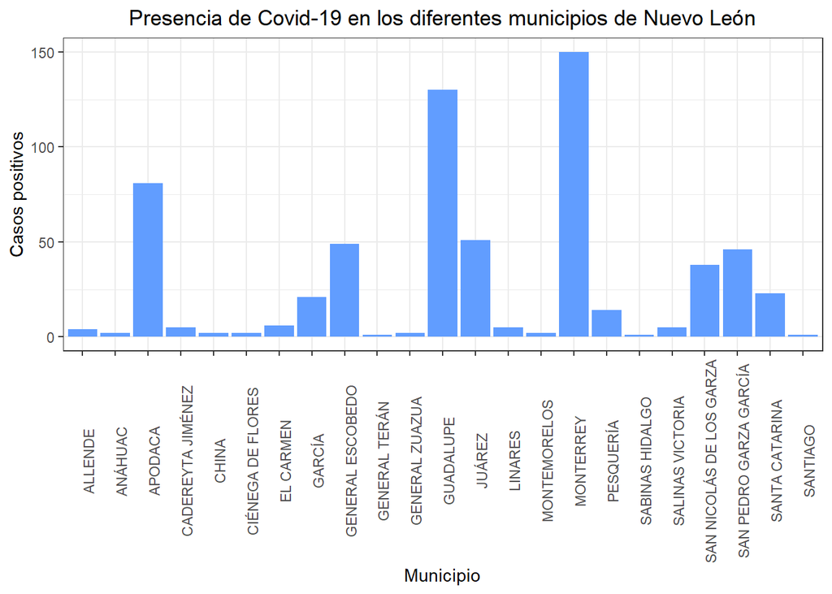

Gracias a la siguiente gráfica podemos interpretar que se ha presentado un mayor número de contagios en hombres.

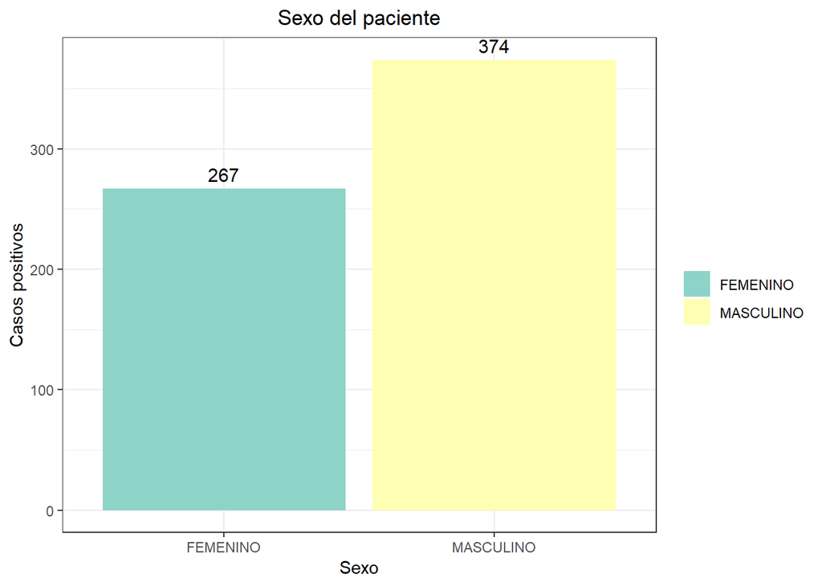

Las instituciones de salud que mayor apoyo han brindado han sido:

[figure not shown]

La vigilancia centinela se realiza a través del sistema de unidades de salud monitoras de enfermedades respiratorias (USMER). Las USMER incluyen unidades médicas del primer, segundo o tercer nivel de atención y también participan como USMER las unidades de tercer nivel que por sus características contribuyen a ampliar el panorama de información epidemiológica, entre ellas las que cuenten con especialidad de neumología, infectología o pediatría.

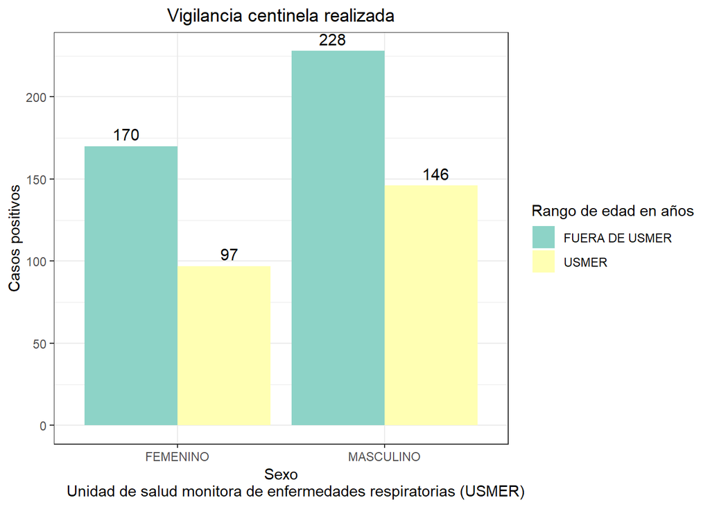

La gráfica que representa el rango de edad nos demuestra que los jovenes de entre 21 30 años y de 41 a 50 años son los más propensos a contraer el virus, esto puede deberse a que en Nuevo León, estos dos grupos representan la mayor parte de la población.

Podemos observar que en hombres son los jóvenes quienes van a la cabeza, mientras que en mujeres son en el rango de edad de 41 a 50 años.

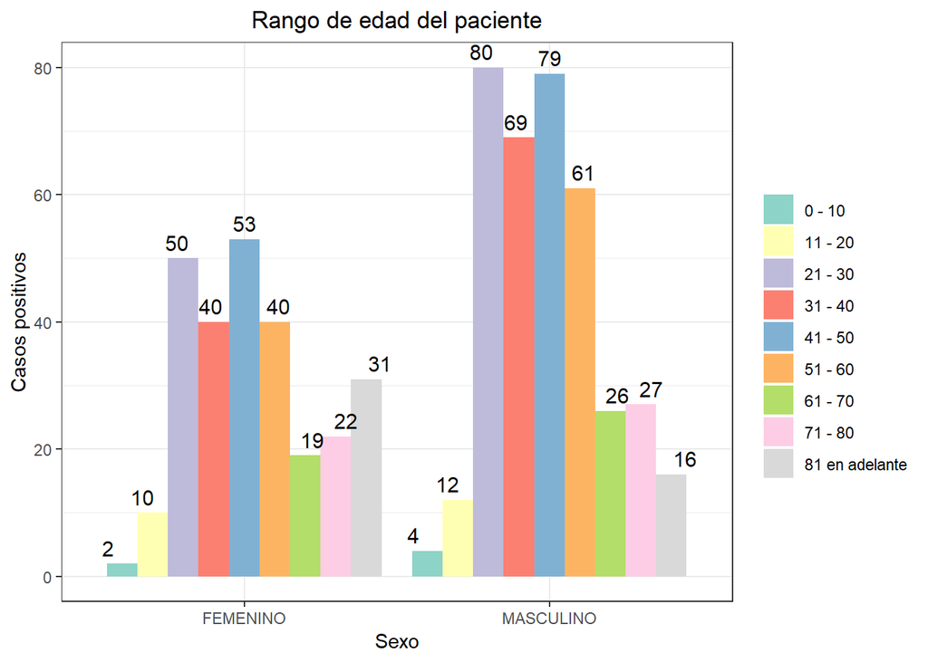

## Las siguientes gráficas presentan complicaciones médicas que presentaron los pacientes.

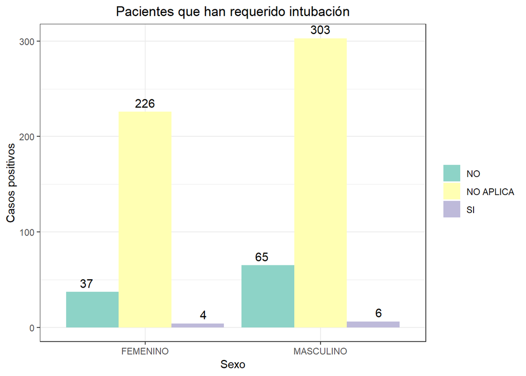

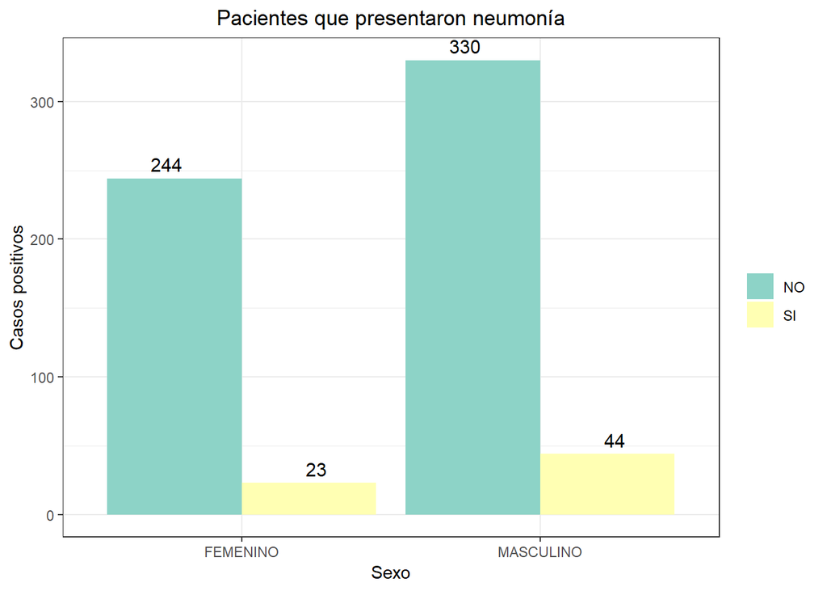

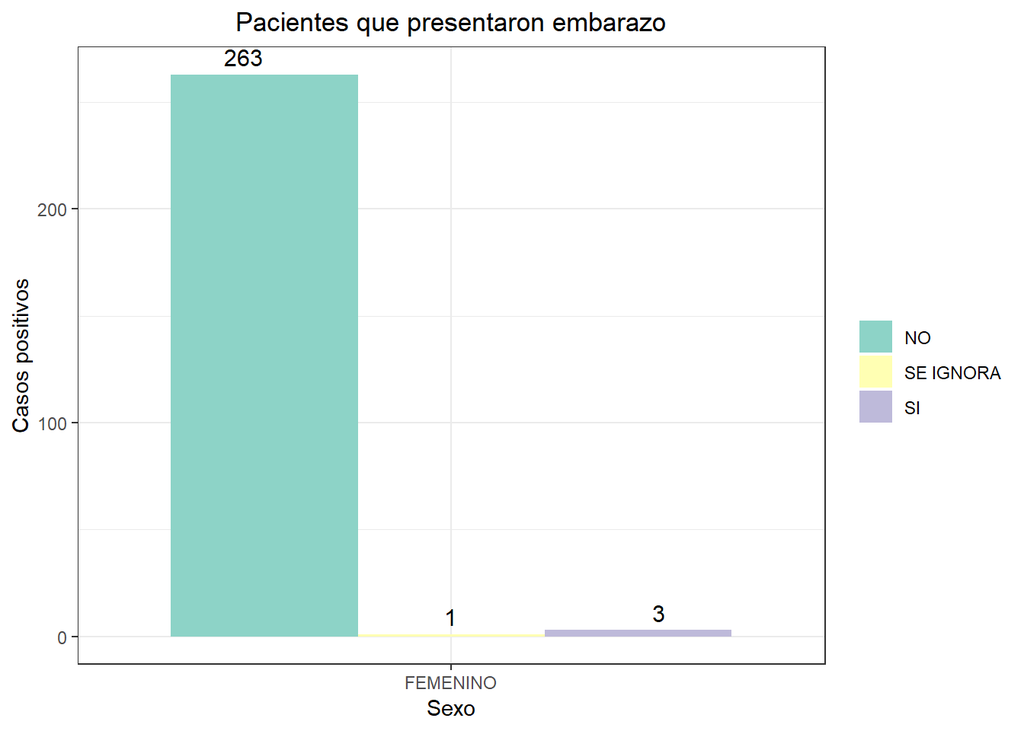

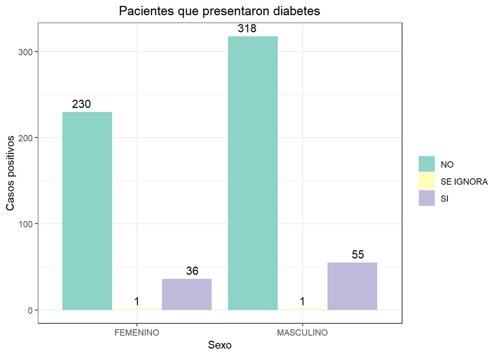

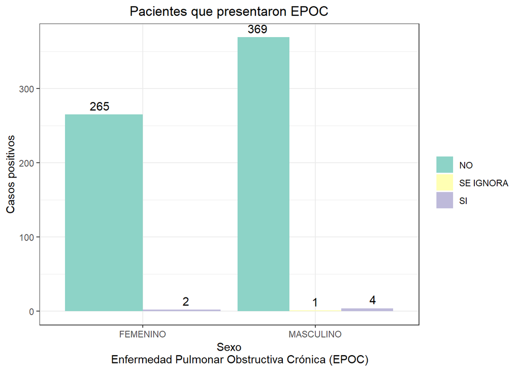

**NOTA** Se puede observar que en mujeres hay mayor probabilidad de presentar asma que en hombres.

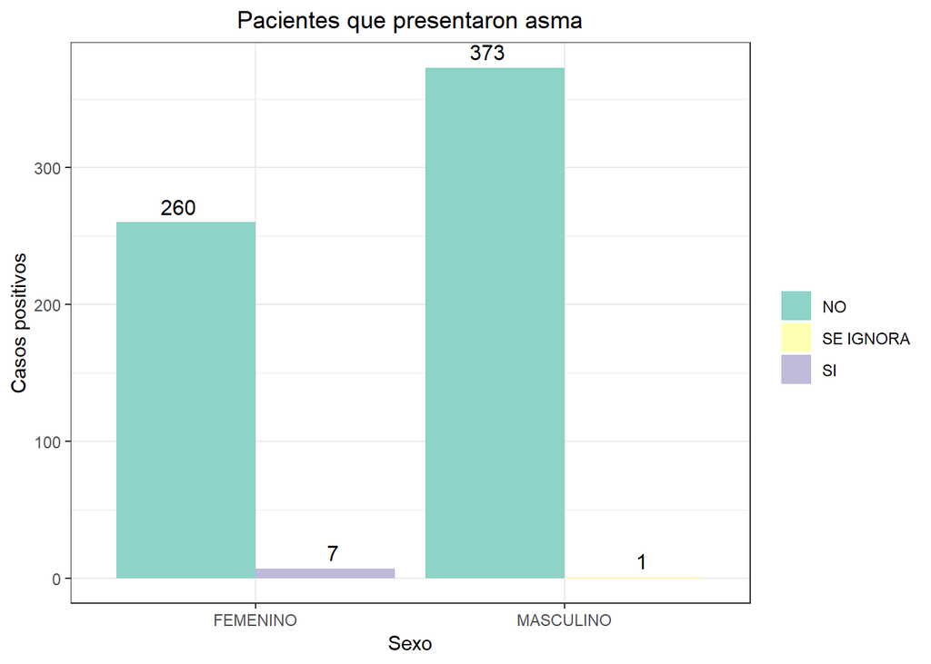

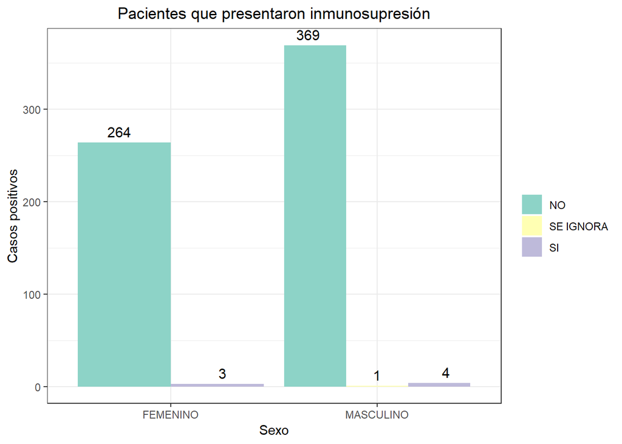

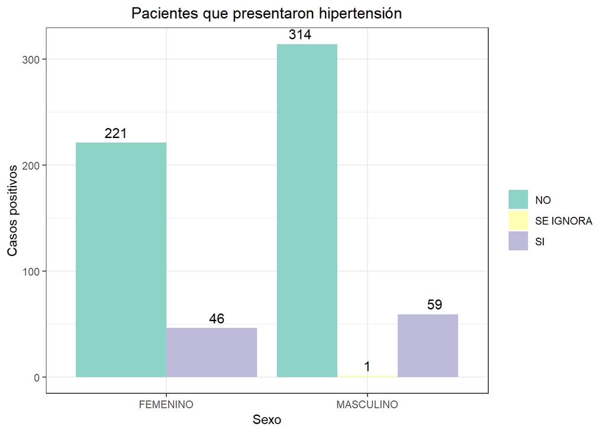

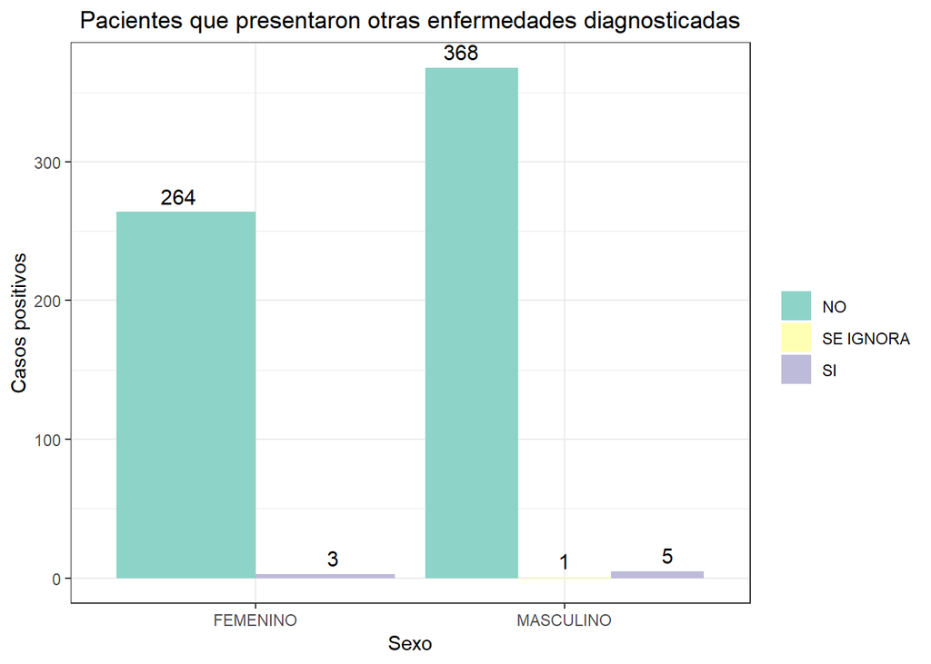

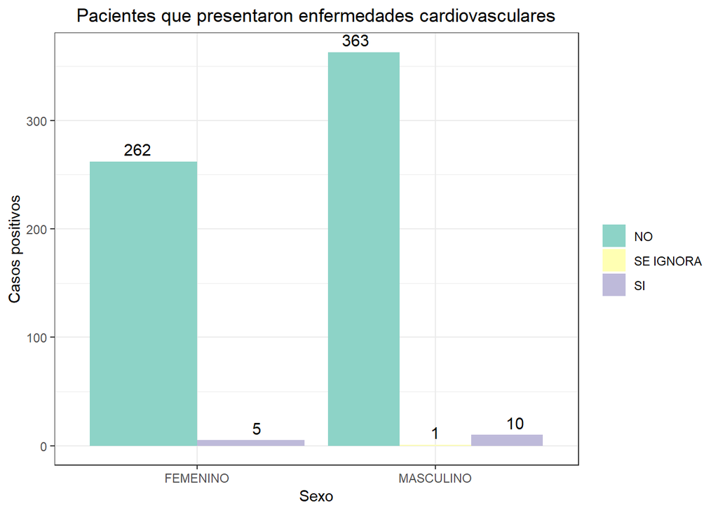

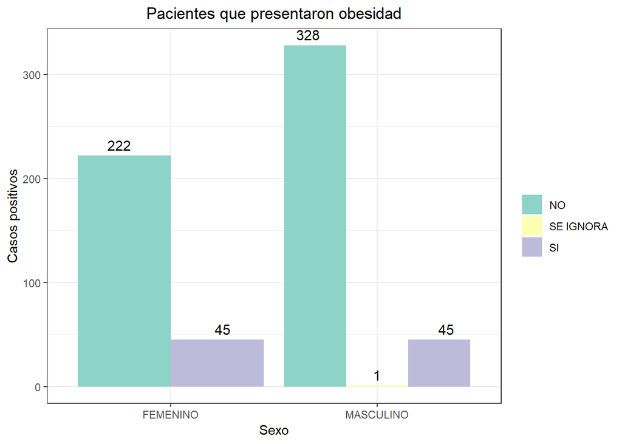

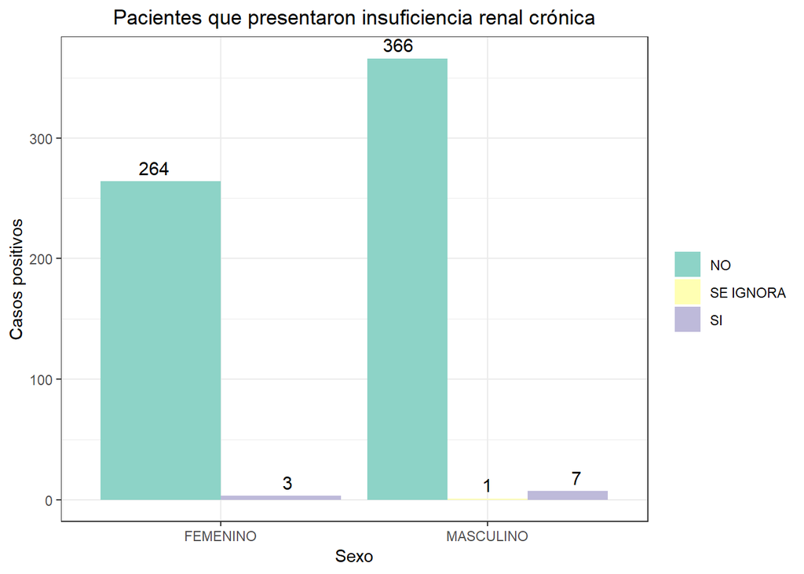

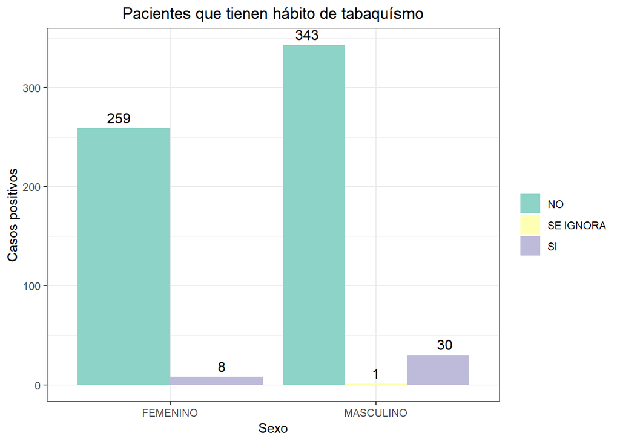

**NOTA IMPORTANTE**

Podemos observar que es más notable la diferencia de quienes afirmaron no haber tenido contacto con personas infectadas a diferencia de quienes afirmaron haberlo tenido en el caso de varones.

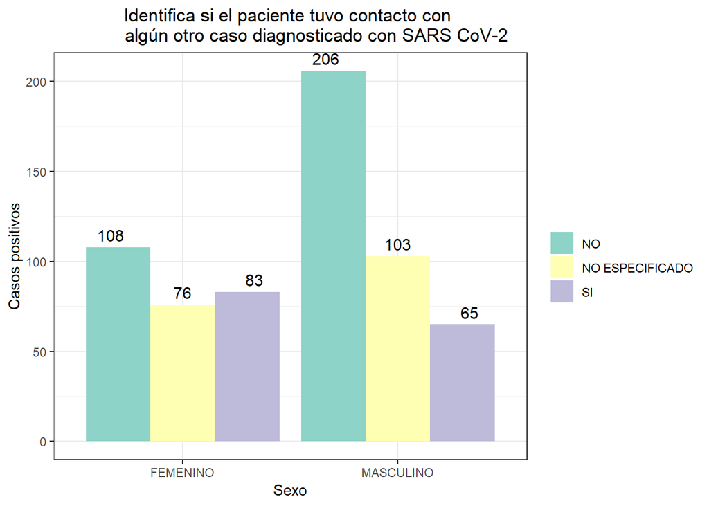

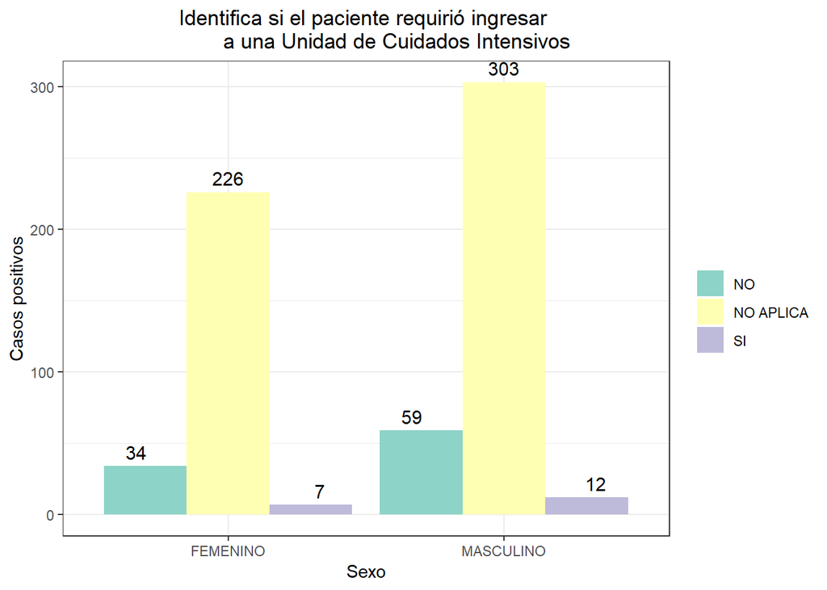

Podemos observar que a partir de marzo (Fecha en que inicia la cuarentena) los números comenzaron a decreser hasta el inicio de la fase 2, donde hubo una considerable subida y bajada.

A finales de abril y comienzos de mayo inician los picos más altos registrados, esto puede deberse a los festejos y puentes entre estas fechas, dónde en cierto tipo de negocios se agrupó mucha gente aumentando el riesgo de contagio.

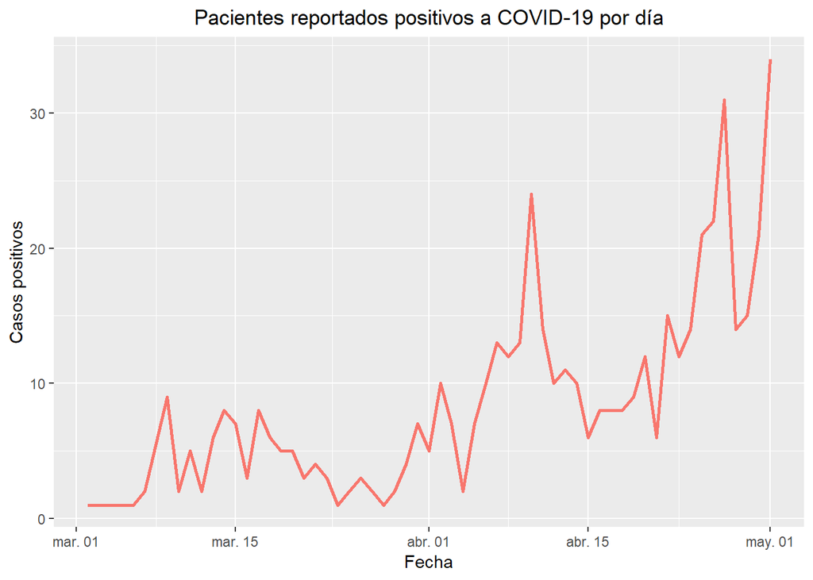

Los picos extremos en la gráfica son debido a las pocas muertes que han ocurrido en Nuevo León por el virus, siendo 3 muertes por día el pico más elevado que se ha registrado.

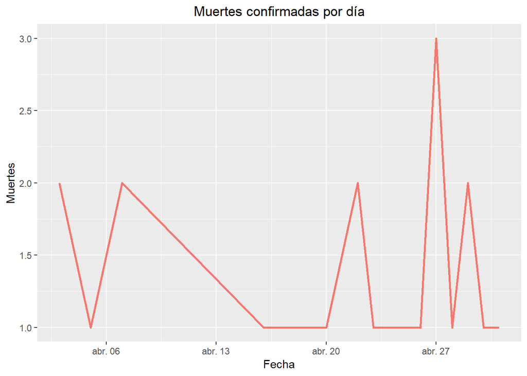

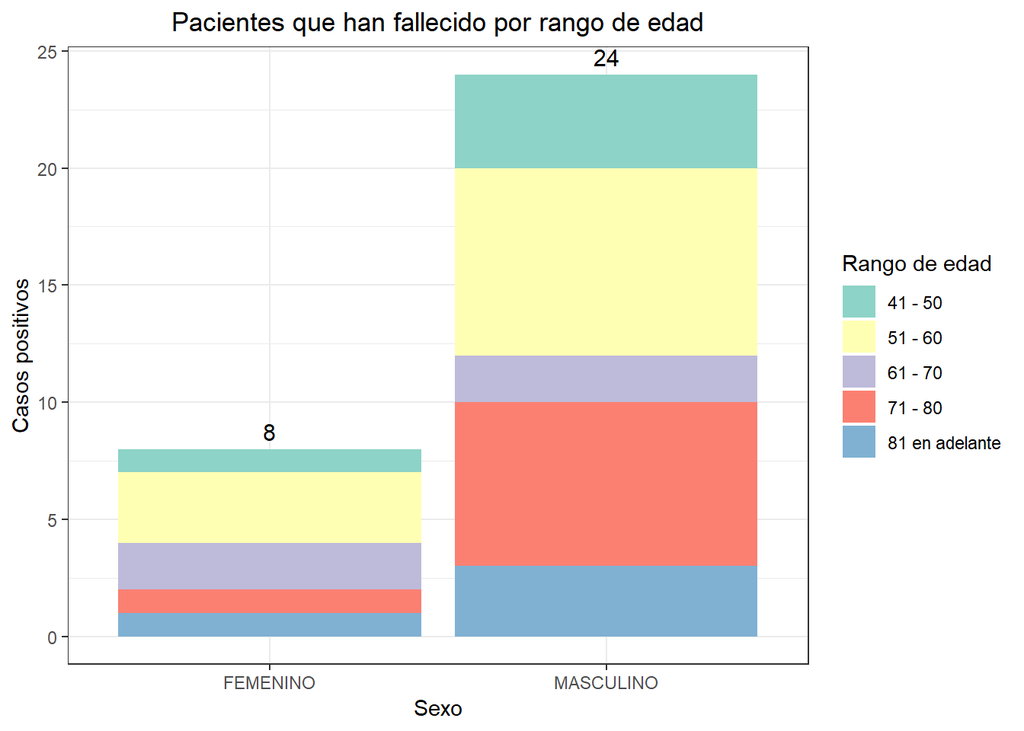

## Reconocimiento de patrones en personas infectadas

Se realizó una metodología de CLARA (Clustering Large Applications) basada en K-MEANS para agrupar personas que compartan características con la finalidad de encontrar que patrones siguen y como se diefencian unos grupos de otros.

Para encontrar el número óptimo de grupos se realizó una diferencia de cuadrados entre cada grupo y se seleccionaron gracias a la metodología “Elbow”, donde podemos observar que el número óptimo de grupos es de 4.

(Para mayor información del aloritmo K-MEANS anexo el siguiente artículo de públicado por la universidad de Stanford: https://stanford.edu/~cpiech/cs221/handouts/kmeans.html)

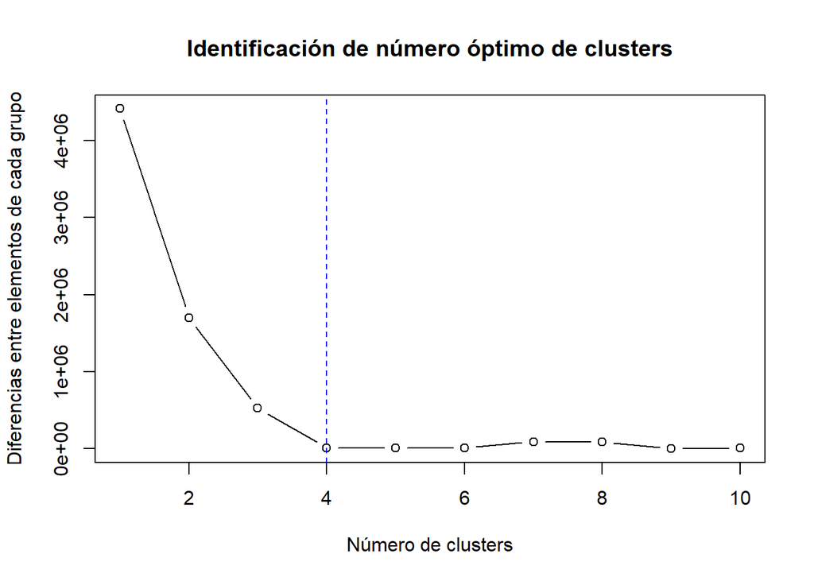

La siguiente gráfica representa la separación de pacientes por grupos.

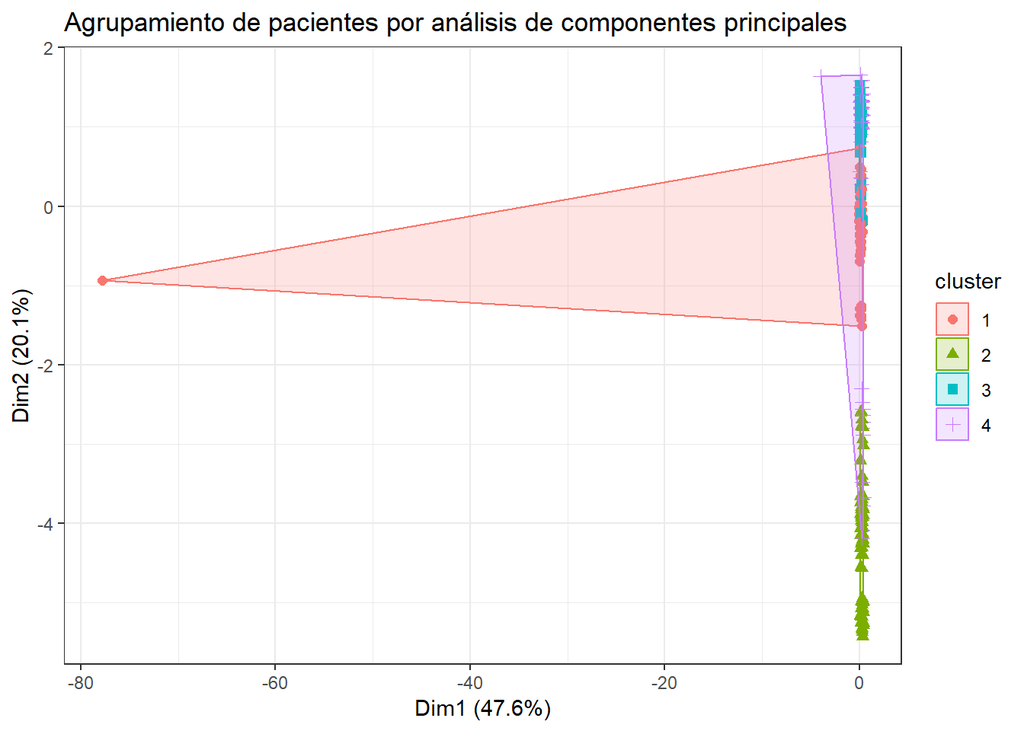

La siguiente tabla describe los patrones presentados

|  | Cluster 1 | Cluster 2 | Cluster 3 | Cluster 4 |
| --- | --- | --- | --- | --- |
| Origen | FUERA DE USMER | USMER | FUERA DE USMER | FUERA DE USMER |
| Institución que brindó atención | IMSS | IMSS | SSA | SSA |
| Sexo | MASCULINO | MASCULINO | MASCULINO | FEMENINO |
| Tipo de paciente | AMBULATORIO | HOSPITALIZADO | AMBULATORIO | AMBULATORIO |
| Fue intubado? | NO APLICA | NO | NO APLICA | NO APLICA |
| Presentó neumonía? | NO | NO | NO | NO |
| Rango de edad | 41 - 50 | 51 - 60 | 31 - 40 | 41 - 50 |
| Presentó un embarazo? | NO APLICA | NO APLICA | NO APLICA | NO |
| Presentó diabetes? | NO | NO | NO | NO |
| Presentó EPOC? | NO | NO | NO | NO |
| Presentó ASMA? | NO | NO | NO | NO |
| Presentó Inmunosupresión? | NO | NO | NO | NO |
| Presentó hipertensión | NO | NO | NO | NO |
| Presentó otra enfermedad? | NO | NO | NO | NO |
| Presentó problemas cardiovasculares? | NO | NO | NO | NO |
| Presentó obesidad? | NO | NO | NO | NO |
| Presentó insuficiencia renal? | NO | NO | NO | NO |
| Presentó hábito de tabaquismo? | NO | NO | NO | NO |
| Tuvo contacto con otro positivo? | NO ESPECIFICADO | NO ESPECIFICADO | NO | NO |
| Requirió cuidados intensivos? | NO APLICA | NO | NO APLICA | NO APLICA |